## 使用梯度下降法训练

[figure not shown]

# 实现多元线性回归

多元线性回归正规方程解

优点：不需要对数据做归一化处理 缺点：时间复杂度O(n***3)

[figure not shown]

```python
from sklearn import datasets
import numpy as np

boston = datasets.load_boston()

X = boston.data
y = boston.target

X = X[y < 50.0]
y = y[y < 50.0]
```

```python
X.shape
```

```
(490, 13)
```

```python
X[:5, :]
```

```
array([[6.3200e-03, 1.8000e+01, 2.3100e+00, 0.0000e+00, 5.3800e-01,
        6.5750e+00, 6.5200e+01, 4.0900e+00, 1.0000e+00, 2.9600e+02,
        1.5300e+01, 3.9690e+02, 4.9800e+00],
       [2.7310e-02, 0.0000e+00, 7.0700e+00, 0.0000e+00, 4.6900e-01,
        6.4210e+00, 7.8900e+01, 4.9671e+00, 2.0000e+00, 2.4200e+02,
        1.7800e+01, 3.9690e+02, 9.1400e+00],
       [2.7290e-02, 0.0000e+00, 7.0700e+00, 0.0000e+00, 4.6900e-01,
        7.1850e+00, 6.1100e+01, 4.9671e+00, 2.0000e+00, 2.4200e+02,
        1.7800e+01, 3.9283e+02, 4.0300e+00],
       [3.2370e-02, 0.0000e+00, 2.1800e+00, 0.0000e+00, 4.5800e-01,
        6.9980e+00, 4.5800e+01, 6.0622e+00, 3.0000e+00, 2.2200e+02,
        1.8700e+01, 3.9463e+02, 2.9400e+00],
       [6.9050e-02, 0.0000e+00, 2.1800e+00, 0.0000e+00, 4.5800e-01,
        7.1470e+00, 5.4200e+01, 6.0622e+00, 3.0000e+00, 2.2200e+02,
        1.8700e+01, 3.9690e+02, 5.3300e+00]])
```

```python
y[:5]
```

```
array([24. , 21.6, 34.7, 33.4, 36.2])
```

```python
def train_test_split(X, y, test_ratio=0.2, seed=None):
    """将数据 X 和 y 按照test_ratio分割成X_train, X_test, y_train, y_test"""
    assert X.shape[0] == y.shape[0], \
        "the size of X must be equal to the size of y"
    assert 0.0 <= test_ratio <= 1.0, \
        "test_ration must be valid"

    if seed:
        np.random.seed(seed)
    #permutation不直接在原来的数组上进行操作，而是返回一个新的打乱顺序的数组，并不改变原来的数组
    #shuffle直接在原来的数组上进行操作，改变原来数组的顺序，无返回值
    shuffled_indexes = np.random.permutation(len(X))

    test_size = int(len(X) * test_ratio)
    test_indexes = shuffled_indexes[:test_size]
    train_indexes = shuffled_indexes[test_size:]

    X_train = X[train_indexes]
    y_train = y[train_indexes]

    X_test = X[test_indexes]
    y_test = y[test_indexes]

    return X_train, X_test, y_train, y_test
```

```python
X_train, X_test, y_train, y_test = train_test_split(X, y, seed=666)
```

```python
from sklearn.metrics import r2_score
#使用r2_score()方法可以看到，预测数据和真实数据越接近，R2越大。当然最大值是 1
#一个模型的R2 值为0还不如直接用平均值来预测效果好；而一个R2值为1的模型则可以对目标变量进行完美的预测。
#从0至1之间的数值，则表示该模型中目标变量中有百分之多少能够用特征来解释。模型也可能出现负值的R2，
#这种情况下模型所做预测有时会比直接计算目标变量的平均值差很多。
```

```python
class LinearRegression:

    def __init__(self):
        """初始化Linear Regression模型"""
        self.coef_ = None
        self.intercept_ = None
        self._theta = None

    def fit_normal(self, X_train, y_train):
        """根据训练数据集X_train, y_train训练Linear Regression模型"""
        assert X_train.shape[0] == y_train.shape[0], \
            "the size of X_train must be equal to the size of y_train"

        X_b = np.hstack([np.ones((len(X_train), 1)), X_train])
        self._theta = np.linalg.inv(X_b.T.dot(X_b)).dot(X_b.T).dot(y_train)

        self.intercept_ = self._theta[0]
        self.coef_ = self._theta[1:]

        return self

    def fit_gd(self, X_train, y_train, eta=0.01, n_iters=1e4):
        """根据训练数据集X_train, y_train, 使用梯度下降法训练Linear Regression模型"""
        assert X_train.shape[0] == y_train.shape[0], \
            "the size of X_train must be equal to the size of y_train"

        def J(theta, X_b, y):
            try:
                return np.sum((y - X_b.dot(theta)) ** 2) / len(y)
            except:
                return float('inf')

        def dJ(theta, X_b, y):
            res = np.empty(len(theta))
            res[0] = np.sum(X_b.dot(theta) - y)
            for i in range(1, len(theta)):
                res[i] = (X_b.dot(theta) - y).dot(X_b[:, i])
            return res * 2 / len(X_b)

        def gradient_descent(X_b, y, initial_theta, eta, n_iters=1e4, epsilon=1e-8):

            theta = initial_theta
            cur_iter = 0

            while cur_iter < n_iters:
                gradient = dJ(theta, X_b, y)
                last_theta = theta
                theta = theta - eta * gradient
                if (abs(J(theta, X_b, y) - J(last_theta, X_b, y)) < epsilon):
                    break

                cur_iter += 1

            return theta

        X_b = np.hstack([np.ones((len(X_train), 1)), X_train])
        initial_theta = np.zeros(X_b.shape[1])
        self._theta = gradient_descent(X_b, y_train, initial_theta, eta, n_iters)

        self.intercept_ = self._theta[0]
        self.coef_ = self._theta[1:]

        return self

    def predict(self, X_predict):
        """给定待预测数据集X_predict，返回表示X_predict的结果向量"""
        assert self.intercept_ is not None and self.coef_ is not None, \
            "must fit before predict!"
        assert X_predict.shape[1] == len(self.coef_), \
            "the feature number of X_predict must be equal to X_train"

        X_b = np.hstack([np.ones((len(X_predict), 1)), X_predict])
        return X_b.dot(self._theta)

    def score(self, X_test, y_test):
        """根据测试数据集 X_test 和 y_test 确定当前模型的准确度"""

        y_predict = self.predict(X_test)
        return r2_score(y_test, y_predict)

    def __repr__(self):
        return "LinearRegression()"
```

```python
reg = LinearRegression()
reg.fit_normal(X_train, y_train)
```

```
LinearRegression()
```

```python
reg.coef_
```

```
array([-1.18919477e-01,  3.63991462e-02, -3.56494193e-02,  5.66737830e-02,
       -1.16195486e+01,  3.42022185e+00, -2.31470282e-02, -1.19509560e+00,
        2.59339091e-01, -1.40112724e-02, -8.36521175e-01,  7.92283639e-03,
       -3.81966137e-01])
```

```python
reg.intercept_
```

```
34.16143549621937
```

```python
reg.score(X_test, y_test)
```

```
0.8129802602658605
```

## 调用sklearn库

```python
# sklearn 中的LinearRegression源码求解线性回归方程参数是首先判断训练集X是不是稀疏矩阵，如是则用Golb&Kahan双对角线化过程方法来求解，否则
# 调用C库LAPACK中的用基于分治法的奇异值分解来求解。这些解法都跟梯度下降没有关系，可见求解线性回归参数理论和实际代码实现还是有很大区别的
from sklearn.linear_model import LinearRegression
model = LinearRegression()
model.fit(X_train, y_train)
```

```
LinearRegression(copy_X=True, fit_intercept=True, n_jobs=1, normalize=False)
```

```python
model.coef_
```

```
array([-1.18919477e-01,  3.63991462e-02, -3.56494193e-02,  5.66737830e-02,
       -1.16195486e+01,  3.42022185e+00, -2.31470282e-02, -1.19509560e+00,
        2.59339091e-01, -1.40112724e-02, -8.36521175e-01,  7.92283639e-03,
       -3.81966137e-01])
```

```python
model.intercept_
```

```
34.16143549624653
```

```python
model.score(X_test, y_test)
```

```
0.8129802602658475
```

## 梯度下降求解

```python
from mpl_toolkits.mplot3d import Axes3D  # plot 3d

class Mul_V_Linear_Regression():
    def __init__(self, dataset, learning_rate):
        self.dataset = dataset
        self.learning_rate = learning_rate
        self.row = len(dataset.data)
        self.col = len(dataset.data[0])+1
        self.features = np.c_[np.ones(self.row), dataset.data]
        self.label = dataset.target
        self.theta = np.zeros(self.col)
        print("self.row=" ,self.row)
        print("self.col=", self.col)

    # hypothesis
    def h(self, x):       # x's size = col+1, the first one is 1.
        res = 0
        for i in range(len(self.theta)):
            res += x[i] * self.theta[i]
        return res

    # cost function
    def J(self):
        temp = 0
        for i in range(self.row):
            temp += pow(self.h(self.features[i]) - self.label[i], 2)
        print("temp",temp)
        return 1 / (2 * self.row) * temp

    # partial derivative
    def pd_theta_J(self, index):
        temp = 0
        for i in range(self.row):
            temp += (self.h(self.features[i]) - self.label[i]) * self.features[i][index]
        return 1 / self.row * temp

    # gradient descent
    def gd(self):
        min_cost = 0.01
        round = 1
        max_round = 100

        while (min_cost < abs(self.J()) and round <= max_round):
            temp = np.zeros(self.col)
            for i in range(self.col):
                temp[i] = self.theta[i] - self.learning_rate * self.pd_theta_J(i)
            self.theta = temp
            for i in range(self.col):
                print(self.theta[i])
            round += 1

        return self.theta
```

```python
print(boston.DESCR)
```

```
Boston House Prices dataset
===========================

Notes
------
Data Set Characteristics:

    :Number of Instances: 506

    :Number of Attributes: 13 numeric/categorical predictive

    :Median Value (attribute 14) is usually the target

    :Attribute Information (in order):
        - CRIM     per capita crime rate by town
        - ZN       proportion of residential land zoned for lots over 25,000 sq.ft.
        - INDUS    proportion of non-retail business acres per town
        - CHAS     Charles River dummy variable (= 1 if tract bounds river; 0 otherwise)
        - NOX      nitric oxides concentration (parts per 10 million)
        - RM       average number of rooms per dwelling
        - AGE      proportion of owner-occupied units built prior to 1940
        - DIS      weighted distances to five Boston employment centres
        - RAD      index of accessibility to radial highways
        - TAX      full-value property-tax rate per $10,000
        - PTRATIO  pupil-teacher ratio by town
        - B        1000(Bk - 0.63)^2 where Bk is the proportion of blacks by town
        - LSTAT    % lower status of the population
        - MEDV     Median value of owner-occupied homes in $1000's

    :Missing Attribute Values: None

    :Creator: Harrison, D. and Rubinfeld, D.L.

This is a copy of UCI ML housing dataset.
http://archive.ics.uci.edu/ml/datasets/Housing


This dataset was taken from the StatLib library which is maintained at Carnegie Mellon University.

The Boston house-price data of Harrison, D. and Rubinfeld, D.L. 'Hedonic
prices and the demand for clean air', J. Environ. Economics & Management,
vol.5, 81-102, 1978.   Used in Belsley, Kuh & Welsch, 'Regression diagnostics
...', Wiley, 1980.   N.B. Various transformations are used in the table on
pages 244-261 of the latter.

The Boston house-price data has been used in many machine learning papers that address regression
problems.

**References**

   - Belsley, Kuh & Welsch, 'Regression diagnostics: Identifying Influential Data and Sources of Collinearity', Wiley, 1980. 244-261.
   - Quinlan,R. (1993). Combining Instance-Based and Model-Based Learning. In Proceedings on the Tenth International Conference of Machine Learning, 236-243, University of Massachusetts, Amherst. Morgan Kaufmann.
   - many more! (see http://archive.ics.uci.edu/ml/datasets/Housing)
```

CRIM：城镇人均犯罪率。

ZN：住宅用地超过 25000 sq.ft. 的比例。

INDUS：城镇非零售商用土地的比例。

CHAS：查理斯河空变量（如果边界是河流，则为1；否则为0）。

NOX：一氧化氮浓度。

RM：住宅平均房间数。

AGE：1940 年之前建成的自用房屋比例。

DIS：到波士顿五个中心区域的加权距离。

RAD：辐射性公路的接近指数。

TAX：每 10000 美元的全值财产税率。

PTRATIO：城镇师生比例。

B：1000（Bk-0.63）^ 2，其中 Bk 指代城镇中黑人的比例。

LSTAT：人口中地位低下者的比例。

MEDV：自住房的平均房价，以千美元计。

```python
    boston = datasets.load_boston()
    x = boston.data[:, 5]
    y = boston.data[:, 12]
    z = boston.target

    boston.data = np.c_[x, y]   # only 5th and 12th is linear
    mul = Mul_V_Linear_Regression(boston, 0.008)
    theta = mul.gd()
```

[output not shown]

[output cut: 348 more lines]

```
4.816467166268108
-0.6611098469825619
temp 15451.698291543506
0.6504523950906401
4.815972040354769
-0.6625960304669501
temp 15451.685485166461
0.6504491943905308
4.816553265814916
-0.6612525860671017
temp 15451.674304715141
0.6502808074842957
4.816127099704119
-0.6625319471401104
temp 15451.664522832236
```

```python
theta
```

```
array([ 0.65028081,  4.8161271 , -0.66253195])
```

```
[12.678019719512825, 40.68276496912081]
```

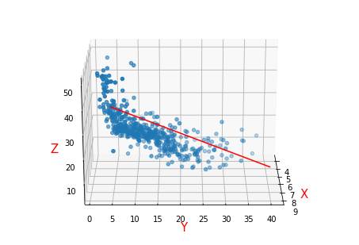

```python
    import matplotlib.pyplot as plt
    # plot scatter
    fig = plt.figure()
    ax = Axes3D(fig)
    ax.scatter(x, y, z)

    # plot line
    x = [8, 9]
    y = [40, 5]
    z = [theta[0]+theta[1]*x[0]+theta[2]*y[0], theta[0]+theta[1]*x[1]+theta[2]*y[1]]
    print(z)
    figure = ax.plot(x, y, z, c='r')

    ax.set_zlabel('Z', fontdict={'size': 15, 'color': 'red'})
    ax.set_ylabel('Y', fontdict={'size': 15, 'color': 'red'})
    ax.set_xlabel('X', fontdict={'size': 15, 'color': 'red'})
    ax.view_init(20, 0)#view_init() 函数可将曲面进行旋转，该函数有两个参数，分别是elev和azim，第一个参数指从哪个高度查看曲面，第二个参数指旋转的角度
    plt.show()
```

利用梯度下降求解多元线性回归-case2

```python
import pandas as pd
import numpy as np
class linearRegrassion:



    def gradientDescent(X,Y,theta,alpha,iters):
        def costFunc(X,Y,theta):
            inner = np.power((X*theta.T)-Y,2)
            return np.sum(inner)/(2*len(X))

        temp = np.mat(np.zeros(theta.shape))
        cost = np.zeros(iters)
        thetaNums = int(theta.shape[1])
        print(thetaNums)
        for i in range(iters):
            error = (X*theta.T-Y)
            for j in range(thetaNums):
                derivativeInner = np.multiply(error,X[:,j])
                temp[0,j] = theta[0,j] - (alpha*np.sum(derivativeInner)/len(X))

            theta = temp
            cost[i] = costFunc(X,Y,theta)

        return theta,cost
```

auto-mpg.data 数据集说明 一辆汽车的各种性能怎样影响它的燃料效率？

为了尝试回答这个问，我们将会使用来自于卡内基梅隆大学提供的一些汽车的燃料效率的一个数据集。

这个数据集是由加州大学欧文分校通过 their machine learning repository收集的。从侧面说来，当你开始着手通过机器学习研究数据，UCI机器学习仓库包含的许多小的数据集是个不错的的选择。

你会注意到这个数据文件夹里包含了很多的文件。我们将会使用 auto-mpg.data，它在燃料效率（mpg 列）缺失的8行已经被删掉了。尽管文件的后缀名是 .data, 它被重新写入了一个文本文件，并且你可以通过任何文本编译器打开它。当你通过一个文本编译器打开 auto-mpg.data ，你会注意到在文件每一行的值都通过白色的变量值加以区分

```
 cylinders----发动机里的气缸（cylinders）数量

 displacement-----发动机的位移（displacement）

 horsepower------发动机的马力（horsepower ）

 weight------汽车的重量。

 acceleration-------汽车的加速性能

 model year----汽车类型的生产年份（比如：70代表这款汽车类型始发于1970年）
```

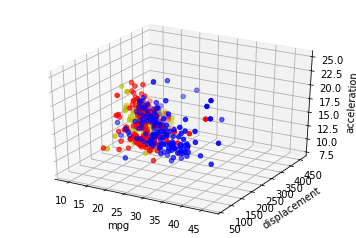

```python
from io import StringIO
from urllib import request
import matplotlib.pyplot as plt
from mpl_toolkits.mplot3d import Axes3D
from matplotlib import cm
import ssl
import pandas as pd
import numpy as np

ssl._create_default_https_context = ssl._create_unverified_context

names =["mpg","cylinders","displacement","horsepower",
        "weight","acceleration","model year","origin","car name"]

url = 'https://archive.ics.uci.edu/ml/machine-learning-databases/auto-mpg/auto-mpg.data'
s = request.urlopen(url).read().decode('utf8')

dataFile = StringIO(s)
cReader = pd.read_csv(dataFile,delim_whitespace=True,names=names)

ax = plt.subplot(111, projection='3d')  # 创建一个三维的绘图工程
ax.scatter(cReader["mpg"][:100],cReader["displacement"][:100],cReader["acceleration"][:100],c='y')
ax.scatter(cReader["mpg"][100:250],cReader["displacement"][100:250],cReader["acceleration"][100:250],c='r')
ax.scatter(cReader["mpg"][250:],cReader["displacement"][250:],cReader["acceleration"][250:],c='b')

ax.set_zlabel('acceleration')  # 坐标轴
ax.set_ylabel('displacement')
ax.set_xlabel('mpg')
plt.show()
```

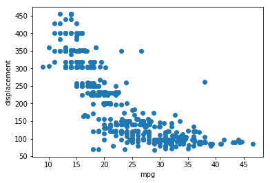

```python
plt.scatter(cReader["mpg"],cReader["displacement"])
plt.xlabel('mpg')
plt.ylabel('displacement')
plt.show()
```

```python
#数据标准化
trainData = cReader[['mpg','displacement','acceleration']]
trainData.insert(0,'ones',1)

print(trainData.head(5))
cols = trainData.shape[1]
X = trainData.iloc[:,0:cols-1]
Y = trainData.iloc[:,cols-1:cols]
X = np.mat(X.values)#mat：创建矩阵
Y = np.mat(Y.values)

for i in range(1,3):
    X[:,i] = (X[:,i] - min(X[:,i])) / (max(X[:,i]) - min(X[:,i]))
print(X[:5:,:3])
#Y[:,0] = (Y[:,0] - min(Y[:,0])) / (max(Y[:,0]) - min(Y[:,0]))
print(Y[:5,0])
```

```
   ones   mpg  displacement  acceleration
0     1  18.0         307.0          12.0
1     1  15.0         350.0          11.5
2     1  18.0         318.0          11.0
3     1  16.0         304.0          12.0
4     1  17.0         302.0          10.5
[[1.         0.2393617  0.61757106]
 [1.         0.15957447 0.72868217]
 [1.         0.2393617  0.64599483]
 [1.         0.18617021 0.60981912]
 [1.         0.21276596 0.60465116]]
[[12. ]
 [11.5]
 [11. ]
 [12. ]
 [10.5]]
```

```python
#开始回归
theta_n = (X.T*X).I*X.T*Y
print(theta_n)

theta = np.mat([0,0,0])
iters = 100000
alpha = 0.001

finalTheta,cost = linearRegrassion.gradientDescent(X,Y,theta,alpha,iters)
print(finalTheta)
print(cost)
```

```
[[17.74518558]
 [-0.63629322]
 [-5.95952521]]
3
[[15.47017446  2.99065096 -3.31870705]]
[124.67279846 124.37076615 124.06949161 ...   2.77449658   2.77449481
   2.77449304]
```

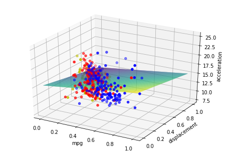

```python
x1 = np.linspace(X[:,1].min(),X[:,1].max(),100)
x2 = np.linspace(X[:,2].min(),X[:,2].max(),100)


x1,x2 = np.meshgrid(x1,x2)
f = finalTheta[0,0] + finalTheta[0,1]*x1 + finalTheta[0,2]*x2

fig = plt.figure()
Ax = Axes3D(fig)
Ax.plot_surface(x1, x2, f, rstride=1, cstride=1, cmap=cm.viridis,label='prediction')

Ax.scatter(X[:100,1],X[:100,2],Y[:100,0],c='y')
Ax.scatter(X[100:250,1],X[100:250,2],Y[100:250,0],c='r')
Ax.scatter(X[250:,1],X[250:,2],Y[250:,0],c='b')

Ax.set_zlabel('acceleration')  # 坐标轴
Ax.set_ylabel('displacement')
Ax.set_xlabel('mpg')

plt.show()
```

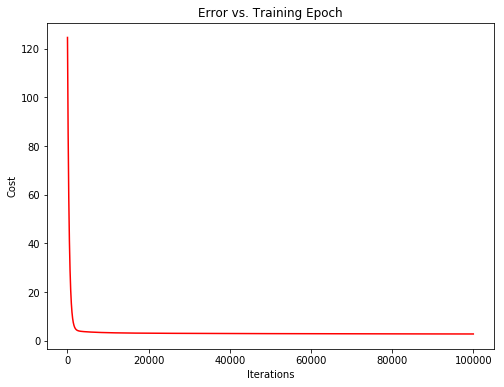

```python
fig, bx = plt.subplots(figsize=(8,6))#figsize长度为inch
bx.plot(np.arange(iters), cost, 'r')
bx.set_xlabel('Iterations')
bx.set_ylabel('Cost')
bx.set_title('Error vs. Training Epoch')
plt.show()
```

## python利用梯度下降求多元线性回归

```python
from timeit import timeit
```

```python
# 批量创造一些数据
# y = w0*x0+w1*x1+w2*x2+w3*x3...wn*xn
# 我们要回归的w先提前随机生成
# 然后给出一些x，和w相乘后得到一些y，再加一些高斯噪声
# 即 y=wx+noise
# data_num生成的数据量，weight_num w的维度
def loadDataSet(data_num,weight_num):
    x = np.random.random((data_num,weight_num))
    w = np.random.random((weight_num,1))
    mu, sigma = 0, 0.1  # 均值与标准差
    noise = np.random.normal(mu, sigma, (data_num, 1))
    y = x.dot(w)+ noise
    print ('groundtruth_weight:')
    print (w)
    return x, y
```

```python
#优化的代价函数是关于所有数据样本的loss，计算整个样本的loss后才更新权值
# 参数更新向量形式：W=W−1m∗(XT(W∗X−Y)∗lr  参数更新向量形式：W=W−1m∗(XT(W∗X−Y)∗lr
# 展开：wj=wj−1m∑mi=0(wi∗xi−yi)∗xi∗lr    展开：wj=wj−1m∑i=0m(wi∗xi−yi)∗xi∗lr
# m是所有样本的数量和
# x:(data_num,weight_num)
# init_w:(weight_num,1)
# y:(data_num,1)
def bgd(x,y,init_w,iter_size,lr):
    #start_time = timeit.default_timer()#timeit.default_timer()
    w = init_w
    m = x.shape[0]
    for i in range(iter_size):
        predict = x.dot(w) # predict:(data_num,1)
        # x:(data_num,weight_num) x.T:(weight_num,data_num) y-predit:(data_num,1)
        # grad:(weight_num,1)
        grad = x.T.dot((predict - y)) / m * lr
        w -= grad
    print (w)
    #end_time = timeit.default_timer()
    #print ('the time of cost: ',end_time - start_time)
```

随机梯度下降

```python
# 优化的代价函数是单个数据样本的loss，计算每个样本的loss后就立即更新权值
# 参数更新向量形式：W=W−1m∗(XT(W∗X−Y)∗lr
# 展开：wj=wj−1m∑mi=0(wi∗xi−yi)∗xi∗lr
# 只是：m=1

# 随机梯度下降
# x:(data_num,weight_num)
# init_w:(weight_num,1)
# y:(data_num,1)
def sgd(x, y, init_w, iter_size, lr):
    #start_time = timeit.default_timer()
    w = init_w
    for i in range(iter_size):
        for j in range(x.shape[0]):
            temp_x = x[np.newaxis,j]#newaxis作用就是选取部分的数据增加一个维度
            temp_y = y[np.newaxis, j]
            predict = temp_x.dot(w)
            # x:(1,weight_num) x.T:(weight_num,1) y-predit:(1,1)
            # grad:(weight_num,1)
            grad = temp_x.T.dot((predict - temp_y)) / 1 * lr
            w -= grad
    print (w)
    #end_time = timeit.default_timer()
    #print ('the time of cost: ', end_time - start_time)
```

## 3. 小批量随机梯度下降

优化的代价函数是每块(batch_size)数据样本的loss，计算每快样本的loss后就更新权值

参数更新向量形式：W=W−1m∗(XT(W∗X−Y)∗lr参数更新向量形式：W=W−1m∗(XT(W∗X−Y)∗lr

展开：wj=wj−1m∑mi=0(wi∗xi−yi)∗xi∗lr展开：wj=wj−1m∑i=0m(wi∗xi−yi)∗xi∗lr

只是：m=batch_size

```python
# 随机梯度下降
# x:(data_num,weight_num)
# init_w:(weight_num,1)
# y:(data_num,1)

def minibgd(x,y,init_w,iter_size,lr,batch_size):
   # start_time = timeit.default_timer()
    w = init_w
    batch_predict = np.zeros((batch_size, 1))
    batch_x = np.zeros((batch_size, init_w.shape[0]))
    batch_y = np.zeros((batch_size, 1))
    m = batch_size
    batch_num = 0
    for i in range(iter_size):
        for j in range(x.shape[0]):
            batch_x[batch_num] = x[np.newaxis, j]
            batch_predict[batch_num][0] = batch_x[batch_num].dot(w)
            batch_y[batch_num][0] = y[np.newaxis, j]
            batch_num += 1
            if batch_num==batch_size:
                batch_num = 0
                # x:(batch_size,weight_num) x.T:(weight_num,batch_size)
                # y-predit:(batch_size,1)
                # grad:(weight_num,1)
                grad = batch_x.T.dot((batch_predict - batch_y)) / m *lr
                w -= grad
    print (w)
    #end_time = timeit.default_timer()
    #print ('the time of cost: ', end_time - start_time)
```

# 4. 测试

```python
data_num = 2000
weight_num = 5
x, y = loadDataSet(data_num,weight_num)
mu, sigma = 0, 0.1  # 均值与标准差
w = np.random.normal(mu, sigma, (weight_num,1))
```

```
groundtruth_weight:
[[0.61353583]
 [0.71592042]
 [0.72756863]
 [0.28306158]
 [0.49172797]]
```

```python
%timeit bgd(x,y,w.copy(),100,0.1)
%timeit sgd(x,y,w.copy(),100,0.1)
%timeit minibgd(x,y,w.copy(),100,0.1,20)
```

[output not shown]

[output cut: 4083 more lines]

```
 [0.71900922]
 [0.74123485]
 [0.26813497]
 [0.48502961]]
[[0.61992186]
 [0.71900922]
 [0.74123485]
 [0.26813497]
 [0.48502961]]
[[0.61992186]
 [0.71900922]
 [0.74123485]
 [0.26813497]
 [0.48502961]]
821 ms ± 2.1 ms per loop (mean ± std. dev. of 7 runs, 1 loop each)
```

由于批梯度下降是整个样本，可以利用numpy里面的矩阵乘法，速度较快。

而随机梯度下降需要每个样本单独乘速度慢些。

小批量梯度是保存到一个batch_size的样本后算乘法，但是由于多了赋值保存等操作还是比批梯度下降慢了些。